# Visual story of my Social Media Usage

Prince De Los Santos

## My social media usage across different applications.

This is my personal visual data story which explores patterns of my social media usage. This data was collected through an observational Google form where each response recorded is equivalent to one social media session. Each observation includes platform used, the number of minutes I spent in that session, the main purpose of using social media, and what period of the day (Morning, afternoon, evening).

This first graph shows which platform I used the most. This gives me an overview of which app appeared most often across my recorded sessions.

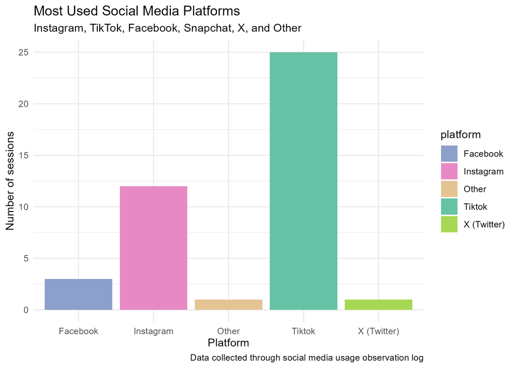

Bar chart showing the number of sessions for each platform.

## Why am I spending time on social media?

This second graph compares the average number of minutes I spent based on each purpose of my social media usage. So instead of showing which was the main purpose of using social media the most often, instead I’m trying to focus on how long these sessions lasted on average based on the different purpose of usage. This is so that I can see if whether some purposes were linked to longer social media sessions like entertainment or passing time.

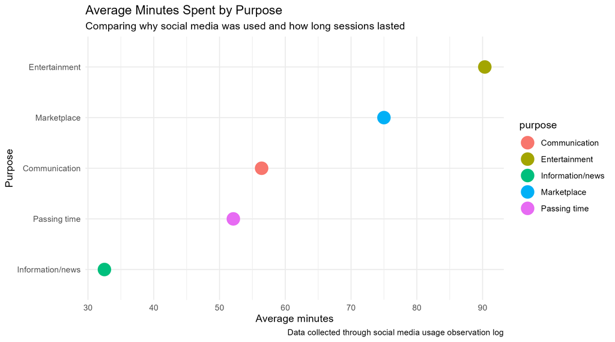

Dot plot showing the average number of minutes spent on social media for each main purpose of use.

## Does my usage change across the week?

This final graph uses the timestamp data from my observation log, the dates were converted into day/month/year R format using the lubridate package, which was then used to show my average social media usage across the week. This helps me see whether my social media sessions were longer on specific days compared to others.

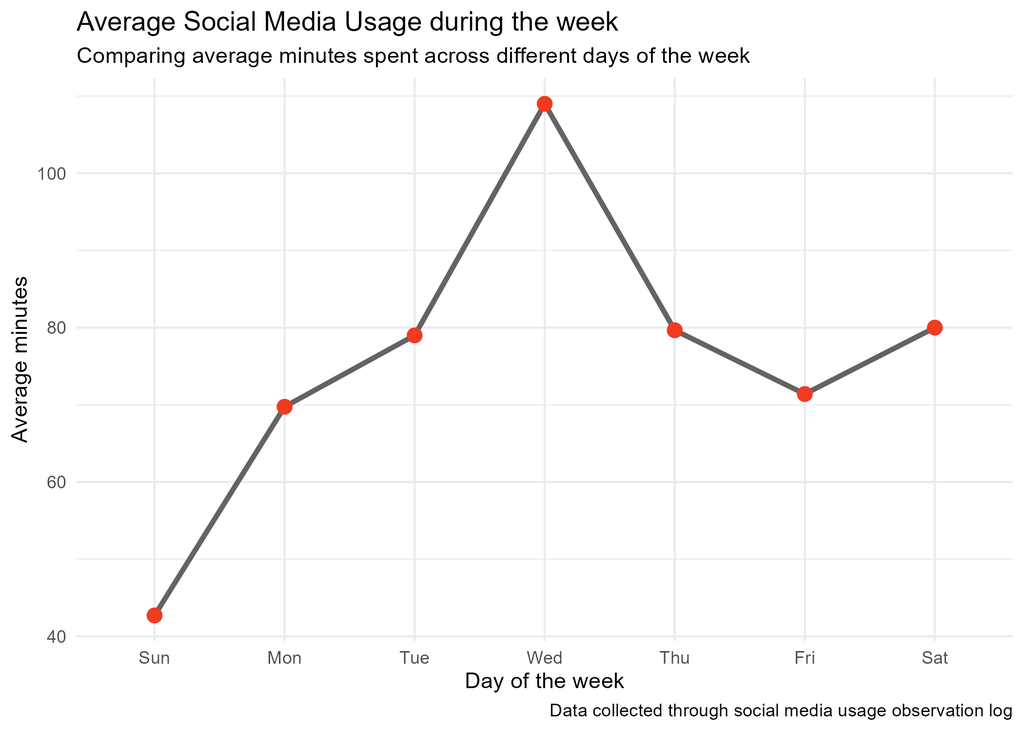

Line graph showing average minutes spent on social media by day of the week.